World Premiere

# Overture

Overture / Angels' Atlas

Choreographies by *Marcos Morau* and *Crystal Pite*

The Spanish choreographer Marcos Morau has emerged as a shooting star of the modern dance scene with his visually spectacular productions. He studied drama theory and choreography in his hometown of Valencia, as well as in Barcelona and New York, without training as a dancer himself. In 2005, he founded his own company, La Veronal, in Barcelona. With this experimental group of dancers and artists, whose members come from different arts sectors, he is a regular guest at the Tanz im August Festival in Berlin. His elaborate stage works have been shown in opera houses and theatres in Lyon, Zurich, Copenhagen and Basel, among others, and captivate audiences and the press alike.

From the 2023/2024 season, he will be artist-in-residence at the Staatsballett Berlin where he will work on a new production for the first time with the Staatsballett ensemble and the Staatskapelle Berlin.

Canadian dancer Crystal Pite was a member of the Ballet British Columbia and the Frankfurt Ballet under the direction of William Forsythe. She made her debut as a choreographer in 1990 with the Ballet BC. Since then, she has developed more than fifty dance pieces for the Ballet de l’Opéra de Paris, the Royal Ballet, the Nederlands Dans Theater I, the Cullberg Ballet and Ballet Frankfurt, among others. Her exhilarating, unconventional work has won numerous international awards, confirming her place as one of the most outstanding artists in recent dance history.

Angels’ Atlas was created by Crystal Pite for the National Ballet of Canada in 2020. It unfolds in front of a constantly changing light installation – a vast, unrecognisable landscape of light and matter. Against this fantastical backdrop, dancing bodies become a sign of human transience as well as vitality. Based on commissioned music by Owen Belton and choral pieces by Peter I. Tchaikovsky and Morten Lauridsen, Angels’ Atlas is a profound work. It is arranged by Crystal Pite for a large ensemble with her usual mastery of classical and modern dance, yet she does not shy away from the challenge of making complex human issues visually and emotionally tangible.

Videos

[figure not shown]

Dates

2024

Info

Staatsoper Unter den Linden

2:00 pm

1 h 35 min incl. one intermission

[Save the date](https://www.staatsballett-berlin.de/en/content/event/184.html)

9.5 – 67

Introduction 45 minutes before curtain.

Family performance

12.00

5

#### Family workshop

To prepare the visit to the opera, participants are introduced to the plot as well as important characters, and they also rehearse short dance scenes. Valid only in combination with a visit to a family performance.

##### Registration required

Tel: 030 34 384-166  
E-mail: contact@tanz-ist-klasse.de

#### Angels' Atlas

Choreography [Crystal Pite](https://www.staatsballett-berlin.de/en/company/persons-detail/peid/crystal-pite/1000488.html)  
Music [Owen Belton](https://www.staatsballett-berlin.de/en/company/persons-detail/peid/owen-belton/2000946.html)  
Additional Music Peter I. Tschaikowsky / Morten Lauridsen  
Reflective Light Backdrop Concept [Jay Gower Taylor](https://www.staatsballett-berlin.de/en/company/persons-detail/peid/jay-gower-taylor/2001101.html)  
Reflective Light Backdrop Design [Jay Gower Taylor](https://www.staatsballett-berlin.de/en/company/persons-detail/peid/jay-gower-taylor/2001101.html) / [Tom Visser](https://www.staatsballett-berlin.de/en/company/persons-detail/peid/tom-visser/2001036.html)  
Set Design [Jay Gower Taylor](https://www.staatsballett-berlin.de/en/company/persons-detail/peid/jay-gower-taylor/2001101.html)  
Lighting Design [Tom Visser](https://www.staatsballett-berlin.de/en/company/persons-detail/peid/tom-visser/2001036.html)  
Kostüm [Nancy Bryant](https://www.staatsballett-berlin.de/en/company/persons-detail/peid/nancy-bryant/2000945.html)  
Choreographische Assistenz und Einstudierung [Spencer Dickhaus](https://www.staatsballett-berlin.de/en/company/persons-detail/peid/spencer-dickhaus/2000944.html)

#### Overture

Choreography and Staging [Marcos Morau](https://www.staatsballett-berlin.de/en/company/persons-detail/peid/marcos-morau/1000486.html)  
Music Gustav Mahler  
Costumes [Silvia Delagneau](https://www.staatsballett-berlin.de/en/company/persons-detail/peid/silvia-delagneau/2000951.html)  
Set Design [Max Glaenzel](https://www.staatsballett-berlin.de/en/company/persons-detail/peid/max-glaenzel/2000950.html)  
Lighting Design [Marc Salicrú](https://www.staatsballett-berlin.de/en/company/persons-detail/peid/marc-salicru/2000949.html)  
Dramaturgy [Israel Solà](https://www.staatsballett-berlin.de/en/company/persons-detail/peid/israel-sola/2001126.html)  
Assistants to the Choreographer [Shay Partush](https://www.staatsballett-berlin.de/en/company/persons-detail/peid/shay-partush/2001128.html) / [Valentin Goniot](https://www.staatsballett-berlin.de/en/company/persons-detail/peid/valentin-goniot/2001124.html)  
Musical Direction [Marius Stravinsky](https://www.staatsballett-berlin.de/en/company/persons-detail/peid/marius-stravinsky/2000948.html)  
Staatskapelle Berlin

Supported by the Spanish Embassy and the Embassy of Canada, Berlin

[figure not shown]

Ensemble, Foto: Serghei Gherciu

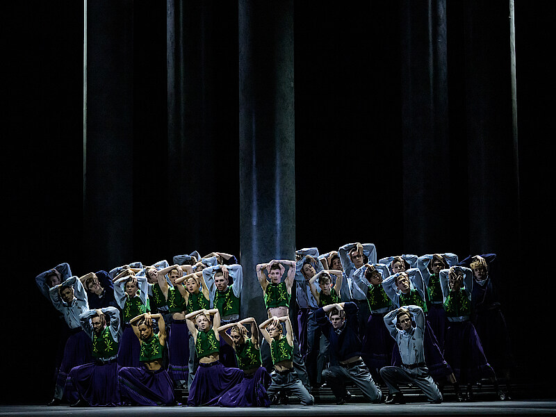

Ensemble, Foto: Serghei Gherciu

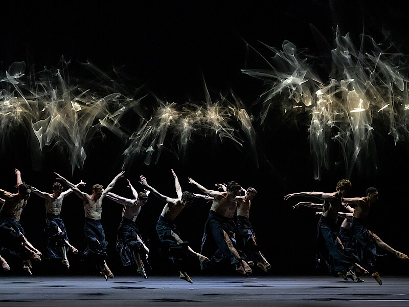

Ensemble, Foto: Serghei Gherciu

[figure not shown]

Ensemble, Foto: Serghei Gherciu

### «I like working in a form that is always in a state of disappearing.»

###### Choreographer Crystal Pite in conversation

*Staatsballett Berlin (SBB)* How did your creation *Angels’ Atlas* come about? What role did the stage and the lighting design play?

*Crystal Pite (CP)* The impetus for the creation of *Angels’ Atlas* came from my partner and set designer Jay Gower Taylor. Through our last few creations, Jay has been developing a system that allows him to manipulate reflected light. Working with lighting designer Tom Visser, they've been discovering myriad ways to deliver light to a surface.

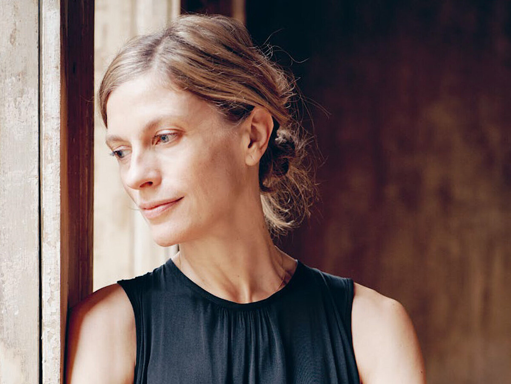

Photo: Anoush Abrar

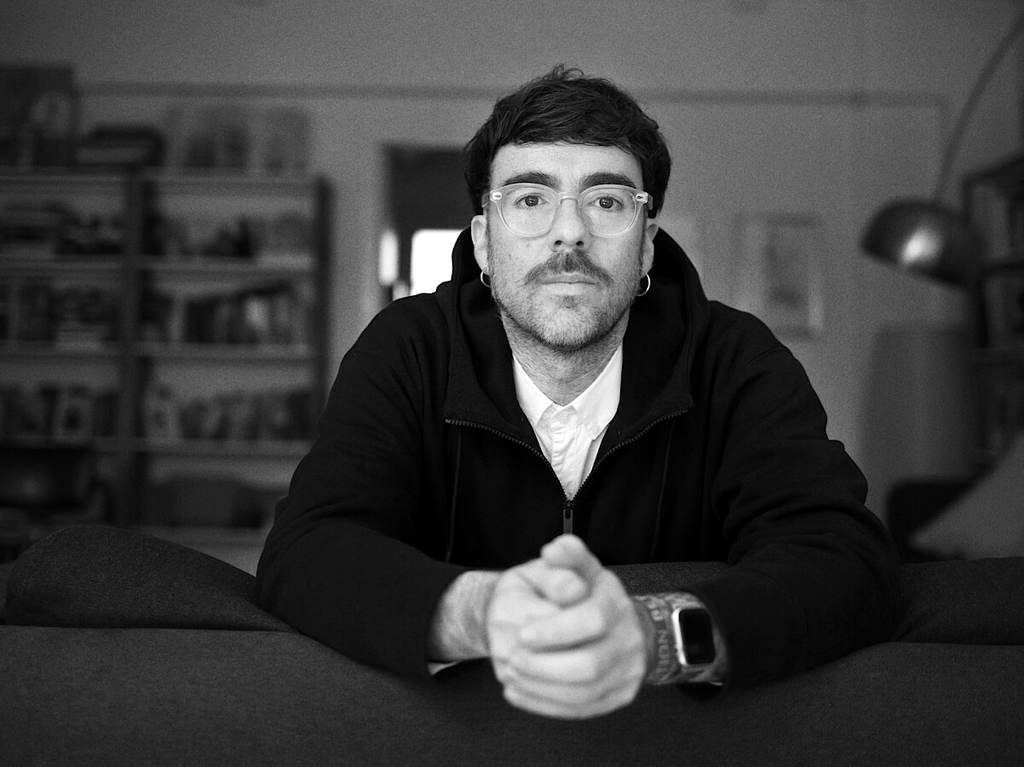

Photo: Albert Pons

### The Wake-Up Caller and Agitator

###### Portrait of choreographer Marcos Morau

The Spanish choreographer Marcos Morau has been the «Artist in Residence» at the Staatsballett Berlin since this season. Until 2026, the internationally celebrated artist will create three choreographies with the ensemble. The beginning of this collaboration is marked by *Overture* with music by Gustav Mahler, and its premiere will be part of the two-part ballet evening on April 28th at the Staatsoper Unter den Linden.

Recommendations

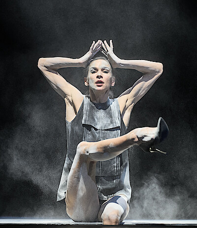

### 2 Chapters Love

Choreographien von *Sol León* und *Sharon Eyal*

Staatsoper Unter den Linden

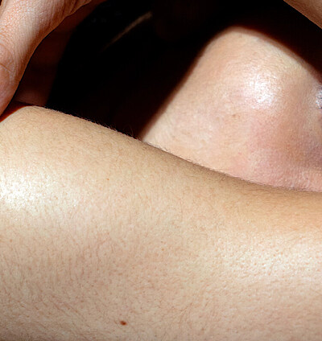

### Next Generation

Choreographien von *Alexander Abdukarimov & Pauline Voisard*, *Gustavo Chalub*, *Aurora Dickie*, *Shaked Heller*, *Theo Just*, *Vivian Assal Koohnavard*, *Ross Martinson*, *Clotilde Tran*, *Dominik White Slavkovský*

Deutsche Oper Berlin | Tischlerei

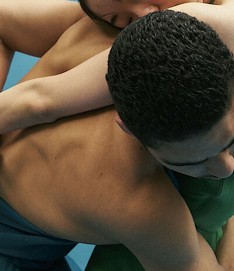

### Gods and Dogs

Choreographien von *Jiří Kylián* und *Crystal Pite*

Staatsoper Unter den Linden